# FDS 2 Project

## Group 28 Pittsburgh

Anmaya Agarwal (anagarwa)

Samay Panwar (samayp)

Catherine Chen

Lauren Liao

```python
import pandas as pd
import numpy as np
import matplotlib.pyplot as plt
import seaborn as sns
from scipy import stats
import json
from datetime import time
import pyarrow
import glob
from sklearn.preprocessing import StandardScaler
from scipy.stats import entropy
from sklearn.neighbors import KernelDensity
from sklearn.cluster import KMeans
from scipy.signal import find_peaks
from sklearn.decomposition import PCA
from tqdm import tqdm
import fastparquet
import statsmodels.formula.api as smf
from sklearn.cluster import KMeans
from sklearn.ensemble import RandomForestRegressor
from sklearn.linear_model import LinearRegression
from sklearn.model_selection import train_test_split
from sklearn.metrics import r2_score
from sklearn.preprocessing import PowerTransformer
import os
from pandas.api.types import CategoricalDtype
pd.set_option('display.max_columns', None)
pd.set_option('display.float_format', lambda x: '%.2f' % x)
sns.set_theme(style="whitegrid") # Clean academic style for plots
```

# Hypothesis 1: Does greater disagreement in the forecast lead to larger shifts in the price?

## 1. Data Cleaning and Pre-processing

```python
firm_level_data = pd.read_csv("HW4_Group28_Pitt_Q1_Cleaned.csv")

print(firm_level_data.shape)
print(firm_level_data.columns)
firm_level_data.head()
```

```
(45193, 35)
Index(['cwiq_code', 'fiscal_year', 'Quarter', 'ticker', 'instrument_sector',
       'instrument_industry', 'reports_at', 'reported_eps', 'reported_revenue',
       'eps_count', 'eps_mean', 'eps_median', 'eps_std', 'eps_skew',
       'eps_kurt', 'eps_entropy', 'eps_kde_peaks', 'eps_skew_pct',
       'eps_mean_surprise_pct', 'eps_median_surprise_pct', 'revenue_count',
       'revenue_mean', 'revenue_median', 'revenue_std', 'revenue_skew',
       'revenue_kurt', 'revenue_entropy', 'revenue_kde_peaks',
       'revenue_skew_pct', 'revenue_mean_surprise_pct',
       'revenue_median_surprise_pct',
       'Stock Price Immediately Before Announcement',
       'Stock Price Immediately After Announcement',
       'Trading Volume Before Announcement',
       'Trading Volume After Announcement'],
      dtype='object')
```

|  | cwiq_code | fiscal_year | Quarter | ticker | instrument_sector | instrument_industry | reports_at | reported_eps | reported_revenue | eps_count | eps_mean | eps_median | eps_std | eps_skew | eps_kurt | eps_entropy | eps_kde_peaks | eps_skew_pct | eps_mean_surprise_pct | eps_median_surprise_pct | revenue_count | revenue_mean | revenue_median | revenue_std | revenue_skew | revenue_kurt | revenue_entropy | revenue_kde_peaks | revenue_skew_pct | … |
| --- | --- | --- | --- | --- | --- | --- | --- | --- | --- | --- | --- | --- | --- | --- | --- | --- | --- | --- | --- | --- | --- | --- | --- | --- | --- | --- | --- | --- | --- | --- |
| 0 | 10033326 | 2015 | 2 | WERN | Industrials | Road & Rail | 2015-07-20 20:00:00 | 0.44 | 534.64 | 1 | 0.43 | 0.43 | NaN | NaN | NaN | 0.00 | 1 | 0.00 | -0.02 | -0.02 | 1 | 537.39 | 537.39 | NaN | NaN | NaN | 0.00 | 1 | 0.00 | … |
| 1 | 10013318 | 2015 | 2 | CAM | Energy | Energy Equipment & Services | 2015-07-23 10:00:00 | 0.83 | 2222.00 | 3 | 0.80 | 0.79 | 0.01 | 1.73 | NaN | 0.64 | 1 | 0.01 | -0.04 | -0.05 | 3 | 2198.33 | 2200.00 | 18.56 | -0.40 | NaN | 1.10 | 1 | -0.00 | … |
| 2 | 10031147 | 2015 | 2 | TEN | Consumer Discretionary | Auto Components | 2015-07-24 10:00:00 | 1.39 | 2130.00 | 4 | 1.35 | 1.35 | 0.01 | 0.00 | 1.50 | 1.04 | 1 | 0.00 | -0.03 | -0.03 | 4 | 2134.32 | 2143.14 | 23.19 | -1.84 | 3.53 | 1.04 | 1 | -0.00 | … |
| 3 | 10029294 | 2015 | 2 | SFG | Financials | Insurance | 2015-07-27 20:00:00 | 1.51 | 734.50 | 2 | 1.25 | 1.25 | 0.04 | NaN | NaN | 0.69 | 1 | 0.00 | -0.18 | -0.18 | 2 | 725.98 | 725.98 | 8.51 | NaN | NaN | 0.69 | 1 | 0.00 | … |
| 4 | 10026594 | 2016 | 1 | PCP | Industrials | Aerospace & Defense | 2015-07-28 10:00:00 | 2.87 | 2412.00 | 11 | 3.05 | 3.06 | 0.03 | -0.28 | 0.19 | 1.85 | 1 | -0.00 | 0.06 | 0.07 | 11 | 2527.64 | 2516.00 | 56.55 | 3.16 | 10.29 | 0.93 | 1 | 0.00 | … |

### 1.1. Data Cleaning

For cleaning the data we do rigourous data cleaning, building upon our work in HW4.

- We drop cols related to EPS since we will do analysis on the estimated revenue. Additionally, EPS and revenue should have a high correlation since revenue is used to calculate EPS
- We drop rows which might not be the most sensible. We did a lot of it in HW4 so it shows a lot of the checks has having 0 rows. We remove rows where revenue is negative (revenue can't negative, PnL can be) or NaN, where trading vol is 0, and no stock price is available. These reasons can be due to a typo or data entry issues.
- We have made a couple of judgement calls as well during data cleaning
  - We have removed those rows where the mean analyst prediction was more than double the reported revenue. It is highly likely there was a typo in recording an analysts prediction or it was a black swan event.
  - We have also removed observations where number of analysts who made the prediction was less than 5. We are using std dev, skewness and kurtosis as major inputs in our models so for these obs we have no values for these statistics and they were very unstable.

After applying all data-quality filters, the cleaned dataset contains 30,135 observations and 23 variables, reduced from the original 45,193 observations and 35 variables.

```python
# Drop EPS related cols as they are not part of the project desc
eps_cols = [col for col in firm_level_data.columns if 'eps' in col.lower()]
firm_level_data_cleaned = firm_level_data.drop(columns=eps_cols)

# Handle Invalid Revenue/Volume/Less num of analysts
print(f"Num of observations with non-positive revenue (not possible) = {len(firm_level_data[firm_level_data['reported_revenue'] <= 0])}")
print(f"Num of observations with NaN revenue (not possible) = {len(firm_level_data[firm_level_data['reported_revenue'].isna()])}")
print(f"Num of observations with non-positive revenue (not possible) = {len(firm_level_data[firm_level_data['revenue_mean'] <= 0])}")
print(f"Num of observations with Trading Volume After Announcement is 0 (Could be a Data Entry Issue)\
 = {len(firm_level_data[firm_level_data['Trading Volume After Announcement'] == 0])}")
print(f"Num of observations with Trading Volume Before Announcement is 0 (Could be a Data Entry Issue)\
 = {len(firm_level_data[firm_level_data['Trading Volume Before Announcement'] == 0])}")
print(f"Num of observations with Estimated Prediction more than double the Reported Revenue (Extreme Outlier, Probably Typo or Data Entry Issue)\
 = {len(firm_level_data[firm_level_data['revenue_mean_surprise_pct'] > 2])}")
print(f"Num of observations where no Stock Price is Available (Data Entry Issue)\
 = {len(firm_level_data_cleaned[firm_level_data_cleaned['Stock Price Immediately Before Announcement'].isna()])}")
print(f"Num of observations where number of analyst ratings are less than 5 (Unreliable/No Skew or Entropy or Std Dev)\
 = {len(firm_level_data_cleaned[firm_level_data_cleaned['revenue_count'] < 5])}")

firm_level_data_cleaned = firm_level_data_cleaned[
    (firm_level_data_cleaned['reported_revenue'] > 0.001) &
    (firm_level_data_cleaned['reported_revenue'].notna()) &
    (firm_level_data_cleaned['revenue_mean'] > 0.001) &
    (firm_level_data_cleaned['Trading Volume After Announcement'] != 0) &
    (firm_level_data_cleaned['Trading Volume Before Announcement'] != 0) &
    (firm_level_data_cleaned['revenue_mean_surprise_pct'] < 2) &
    (firm_level_data_cleaned['Stock Price Immediately Before Announcement'].notna()) &
    (firm_level_data_cleaned['revenue_count'] >= 5)
].reset_index(drop=True)

print(f"New shape after dropping invalid observations: {firm_level_data_cleaned.shape}")

firm_level_data_cleaned.head()
```

```
Num of observations with non-positive revenue (not possible) = 0
Num of observations with NaN revenue (not possible) = 0
Num of observations with non-positive revenue (not possible) = 0
Num of observations with Trading Volume After Announcement is 0 (Could be a Data Entry Issue) = 114
Num of observations with Trading Volume Before Announcement is 0 (Could be a Data Entry Issue) = 1791
Num of observations with Estimated Prediction more than double the Reported Revenue (Extreme Outlier, Probably Typo or Data Entry Issue) = 17
Num of observations where no Stock Price is Available (Data Entry Issue) = 346
Num of observations where number of analyst ratings are less than 5 (Unreliable/No Skew or Entropy or Std Dev) = 13616
New shape after dropping invalid observations: (30135, 23)
```

|  | cwiq_code | fiscal_year | Quarter | ticker | instrument_sector | instrument_industry | reports_at | reported_revenue | revenue_count | revenue_mean | revenue_median | revenue_std | revenue_skew | revenue_kurt | revenue_entropy | revenue_kde_peaks | revenue_skew_pct | revenue_mean_surprise_pct | revenue_median_surprise_pct | Stock Price Immediately Before Announcement | Stock Price Immediately After Announcement | Trading Volume Before Announcement | Trading Volume After Announcement |
| --- | --- | --- | --- | --- | --- | --- | --- | --- | --- | --- | --- | --- | --- | --- | --- | --- | --- | --- | --- | --- | --- | --- | --- |
| 0 | 10026594 | 2016 | 1 | PCP | Industrials | Aerospace & Defense | 2015-07-28 10:00:00 | 2412.00 | 11 | 2527.64 | 2516.00 | 56.55 | 3.16 | 10.29 | 0.93 | 1 | 0.00 | 0.05 | 0.04 | 187.33 | 201.37 | 336522.00 | 427777.00 |
| 1 | 10011639 | 2015 | 2 | ATML | Information Technology | Semiconductors | 2015-07-28 10:00:00 | 306.35 | 10 | 322.56 | 319.38 | 11.89 | 3.09 | 9.69 | 0.64 | 1 | 0.01 | 0.05 | 0.04 | 8.56 | 8.55 | 999235.00 | 1944032.00 |
| 2 | 10014258 | 2015 | 3 | CLC | Industrials | Machinery | 2015-09-16 20:00:00 | 352.23 | 6 | 402.53 | 403.28 | 4.14 | 0.17 | 0.09 | 1.56 | 1 | -0.00 | 0.14 | 0.14 | 55.64 | 48.39 | 43248.00 | 380344.00 |
| 3 | 10022158 | 2015 | 3 | KBH | Consumer Discretionary | Household Durables | 2015-09-24 10:00:00 | 843.16 | 14 | 812.97 | 810.10 | 7.19 | 0.50 | -1.14 | 2.01 | 1 | 0.00 | -0.04 | -0.04 | 14.45 | 14.60 | 1411400.00 | 1770149.00 |
| 4 | 10012058 | 2015 | 2 | BBBY | Consumer Discretionary | Specialty Retail | 2015-09-24 20:00:00 | 2995.00 | 25 | 3027.56 | 3028.00 | 14.92 | -0.25 | -0.58 | 2.10 | 1 | -0.00 | 0.01 | 0.01 | 59.33 | 59.79 | 944498.00 | 2595684.00 |

### 1.2. Create the Response Variable

We create the response variable for this hypothesis which is the log return of the stock before and after the announcement.

Since our primary interest is in the magnitude of the price reaction rather than its direction, we construct the absolute log return. This captures how large the shift in the price is, regardless of the direction.

```python
# Create Response Variable Log Returns
firm_level_data_cleaned['log_return'] = np.log(
    firm_level_data_cleaned['Stock Price Immediately After Announcement'] /
    firm_level_data_cleaned['Stock Price Immediately Before Announcement']
)

# Create variable which is the abs value of the log return
firm_level_data_cleaned['abs_return'] = firm_level_data_cleaned['log_return'].abs()

print("Final Dataset Shape: ", firm_level_data_cleaned.shape)
firm_level_data_cleaned.head()
```

```
Final Dataset Shape:  (30135, 25)
```

|  | cwiq_code | fiscal_year | Quarter | ticker | instrument_sector | instrument_industry | reports_at | reported_revenue | revenue_count | revenue_mean | revenue_median | revenue_std | revenue_skew | revenue_kurt | revenue_entropy | revenue_kde_peaks | revenue_skew_pct | revenue_mean_surprise_pct | revenue_median_surprise_pct | Stock Price Immediately Before Announcement | Stock Price Immediately After Announcement | Trading Volume Before Announcement | Trading Volume After Announcement | log_return | abs_return |
| --- | --- | --- | --- | --- | --- | --- | --- | --- | --- | --- | --- | --- | --- | --- | --- | --- | --- | --- | --- | --- | --- | --- | --- | --- | --- |
| 0 | 10026594 | 2016 | 1 | PCP | Industrials | Aerospace & Defense | 2015-07-28 10:00:00 | 2412.00 | 11 | 2527.64 | 2516.00 | 56.55 | 3.16 | 10.29 | 0.93 | 1 | 0.00 | 0.05 | 0.04 | 187.33 | 201.37 | 336522.00 | 427777.00 | 0.07 | 0.07 |
| 1 | 10011639 | 2015 | 2 | ATML | Information Technology | Semiconductors | 2015-07-28 10:00:00 | 306.35 | 10 | 322.56 | 319.38 | 11.89 | 3.09 | 9.69 | 0.64 | 1 | 0.01 | 0.05 | 0.04 | 8.56 | 8.55 | 999235.00 | 1944032.00 | -0.00 | 0.00 |
| 2 | 10014258 | 2015 | 3 | CLC | Industrials | Machinery | 2015-09-16 20:00:00 | 352.23 | 6 | 402.53 | 403.28 | 4.14 | 0.17 | 0.09 | 1.56 | 1 | -0.00 | 0.14 | 0.14 | 55.64 | 48.39 | 43248.00 | 380344.00 | -0.14 | 0.14 |
| 3 | 10022158 | 2015 | 3 | KBH | Consumer Discretionary | Household Durables | 2015-09-24 10:00:00 | 843.16 | 14 | 812.97 | 810.10 | 7.19 | 0.50 | -1.14 | 2.01 | 1 | 0.00 | -0.04 | -0.04 | 14.45 | 14.60 | 1411400.00 | 1770149.00 | 0.01 | 0.01 |
| 4 | 10012058 | 2015 | 2 | BBBY | Consumer Discretionary | Specialty Retail | 2015-09-24 20:00:00 | 2995.00 | 25 | 3027.56 | 3028.00 | 14.92 | -0.25 | -0.58 | 2.10 | 1 | -0.00 | 0.01 | 0.01 | 59.33 | 59.79 | 944498.00 | 2595684.00 | 0.01 | 0.01 |

### 1.3. Create important features and feature transformation

We compute the coefficient of variation (CV) for revenue because the raw standard deviation naturally scales with firm size (For example - Std Dev of Walmart could be in the billions since their revenue is in hundreds of billions, whereas for smaller companies with less revenue their std dev would be smaller)

Normalizing the standard deviation by the mean allows us to control for firm size and compare analyst disagreement more meaningfully across companies. This also reduces the effect of outliers and ensures that the betas are not being affected by extreme values.

We also create a feature for the absolute surprise which we will use in the another hypothesis. This feature is calculated using the revenue mean surprice pct = (mean analyst revenue estimate + reported revenue ) / (reported revenue)

We then applied Yeo–Johnson transformation and standard scaling on the columns that we will use for our analysis to address non-normality, stabilize variance, and prepare the features for PCA.

```python
# CREATE BASE FEATURES
# Magnitude of Surprise for estimated revenue
firm_level_data_cleaned['abs_surprise'] = firm_level_data_cleaned['revenue_mean_surprise_pct'].abs()

# Coefficient of Variation (CV) = Disagreement normalized by size (standard deviation / mean)
firm_level_data_cleaned['revenue_cv'] = (
    firm_level_data_cleaned['revenue_std'] /
    (firm_level_data_cleaned['revenue_mean'] + 1e-6)
)

# YEO-JOHNSON TRANSFORMATION
# We use this to fix Non-Normality and handle Negative Skew/Kurtosis since they are heavily right tailed due to large companies
features_to_transform = ['revenue_cv', 'revenue_skew', 'revenue_kurt', 'revenue_entropy']
transformed_cols = []

print("\nApplying Yeo-Johnson Transformation & Scaling...")

for col in features_to_transform:
    new_col_name = f"{col}_yj"
    transformed_cols.append(new_col_name)

    # Yeo-Johnson Transform (Fixes Normality)
    firm_level_data_cleaned[new_col_name], _ = stats.yeojohnson(firm_level_data_cleaned[col])

# Standard Scaling (Fixes Variance)
# PCA requires Mean=0, Std=1. Yeo-Johnson doesn't guarantee Std=1, so we scale manually.
scaler = StandardScaler()
firm_level_data_cleaned[transformed_cols] = scaler.fit_transform(firm_level_data_cleaned[transformed_cols])

# Winsorization or Clip any remaining outliers to +/- 4 Sigma
for col in transformed_cols:
    firm_level_data_cleaned[col] = firm_level_data_cleaned[col].clip(-4, 4)

print("Transformation Complete. Features are ready for PCA.")

firm_level_data_cleaned.describe()
```

```
Applying Yeo-Johnson Transformation & Scaling...
Transformation Complete. Features are ready for PCA.
```

|  | cwiq_code | fiscal_year | Quarter | reported_revenue | revenue_count | revenue_mean | revenue_median | revenue_std | revenue_skew | revenue_kurt | revenue_entropy | revenue_kde_peaks | revenue_skew_pct | revenue_mean_surprise_pct | revenue_median_surprise_pct | Stock Price Immediately Before Announcement | Stock Price Immediately After Announcement | Trading Volume Before Announcement | Trading Volume After Announcement | log_return | abs_return | abs_surprise | revenue_cv | revenue_cv_yj | revenue_skew_yj | revenue_kurt_yj | revenue_entropy_yj |
| --- | --- | --- | --- | --- | --- | --- | --- | --- | --- | --- | --- | --- | --- | --- | --- | --- | --- | --- | --- | --- | --- | --- | --- | --- | --- | --- | --- |
| count | 30135.00 | 30135.00 | 30135.00 | 30135.00 | 30135.00 | 30135.00 | 30135.00 | 30135.00 | 30135.00 | 30135.00 | 30135.00 | 30135.00 | 30135.00 | 30135.00 | 30135.00 | 30135.00 | 30135.00 | 30135.00 | 30135.00 | 30135.00 | 30135.00 | 30135.00 | 30135.00 | 30135.00 | 30135.00 | 30135.00 | 30135.00 |
| mean | 10028014.34 | 2018.34 | 2.52 | 2938.15 | 22.60 | 2893.90 | 2906.99 | 162.06 | -0.04 | 5.17 | 1.40 | 1.32 | 0.00 | -0.01 | -0.01 | 82.03 | 82.11 | 901138.48 | 1509465.84 | -0.00 | 0.06 | 0.05 | 0.05 | 0.00 | -0.00 | -0.00 | 0.00 |
| std | 15749.58 | 2.01 | 1.11 | 8130.88 | 39.70 | 7977.56 | 8026.62 | 799.44 | 2.12 | 14.88 | 0.41 | 0.52 | 0.04 | 0.11 | 0.11 | 134.94 | 135.30 | 1681019.08 | 2757783.98 | 0.09 | 0.07 | 0.10 | 0.08 | 1.00 | 0.98 | 0.99 | 1.00 |
| min | 10000048.00 | 2015.00 | 1.00 | 0.04 | 5.00 | 0.04 | 0.03 | 0.00 | -18.05 | -3.33 | 0.00 | 1.00 | -0.44 | -0.99 | -0.99 | 0.22 | 0.22 | 2178.00 | 3487.00 | -1.05 | 0.00 | 0.00 | 0.00 | -1.49 | -4.00 | -3.56 | -2.31 |
| 25% | 10016440.00 | 2017.00 | 2.00 | 238.56 | 7.00 | 235.78 | 235.23 | 4.27 | -1.16 | 0.14 | 1.21 | 1.00 | -0.00 | -0.03 | -0.03 | 25.19 | 25.19 | 170444.50 | 305760.50 | -0.04 | 0.02 | 0.01 | 0.01 | -0.81 | -0.61 | -0.48 | -0.63 |
| 50% | 10025565.00 | 2018.00 | 3.00 | 700.06 | 11.00 | 692.21 | 690.62 | 14.42 | 0.13 | 2.22 | 1.48 | 1.00 | 0.00 | -0.01 | -0.01 | 50.31 | 50.17 | 390549.00 | 674463.00 | 0.00 | 0.04 | 0.03 | 0.02 | -0.30 | -0.03 | 0.07 | 0.04 |
| 75% | 10036244.00 | 2020.00 | 4.00 | 2245.00 | 24.00 | 2220.27 | 2225.25 | 58.56 | 1.32 | 5.29 | 1.70 | 2.00 | 0.01 | 0.02 | 0.01 | 93.00 | 93.26 | 945812.00 | 1581752.50 | 0.04 | 0.08 | 0.06 | 0.05 | 0.67 | 0.62 | 0.52 | 0.71 |
| max | 10086003.00 | 2023.00 | 4.00 | 152871.00 | 1038.00 | 153092.71 | 153066.00 | 22175.57 | 14.08 | 368.84 | 2.26 | 6.00 | 2.59 | 1.90 | 2.37 | 3599.92 | 3467.42 | 44589388.00 | 85158362.00 | 1.33 | 1.33 | 1.90 | 1.85 | 2.13 | 4.00 | 4.00 | 2.90 |

## 2. Data Visualisation

### 2.1. Distribution Check for Features

To validate that the Yeo–Johnson transformation successfully corrected the non-normality problem in the features, we plot the before-and-after distributions for each variable.

The top row shows the original features (revenue_cv, revenue_skew, revenue_kurt, revenue_entropy), all of which display heavy skewness, long tails, and in some cases extreme outliers. These characteristics can distort PCA and regression estimates.

The bottom row presents the corresponding transformed variables (*_yj). After applying the Yeo–Johnson transformation and scaling, the distributions become considerably more symmetric and concentrated, with reduced skewness and stabilized variance. While the transformed features are not perfectly Gaussian, they are substantially closer to normality and therefore better suited for PCA.

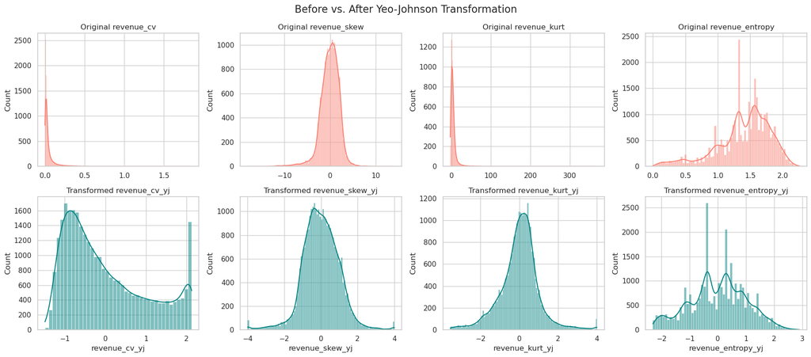

```python
# Define features
shape_cols_yj = ['revenue_cv_yj', 'revenue_skew_yj', 'revenue_kurt_yj', 'revenue_entropy_yj']
target = 'abs_return'

fig, axes = plt.subplots(2, 4, figsize=(18, 8))
fig.suptitle('Before vs. After Yeo-Johnson Transformation', fontsize=16)

raw_cols = ['revenue_cv', 'revenue_skew', 'revenue_kurt', 'revenue_entropy']
for i, col in enumerate(raw_cols):
    sns.histplot(firm_level_data_cleaned[col], kde=True, ax=axes[0,i], color='salmon')
    axes[0,i].set_title(f'Original {col}')
    axes[0,i].set_xlabel('')

    sns.histplot(firm_level_data_cleaned[f'{col}_yj'], kde=True, ax=axes[1,i], color='teal')
    axes[1,i].set_title(f'Transformed {col}_yj')

plt.tight_layout()
plt.show()
```

### 2.2. How does disagreement/entropy change over time?

We compute yearly averages of the coefficient of variation (analyst disagreement) and entropy (forecast uncertainty), normalizing both to a 2015=100 index. The time-series plot shows a sharp spike in disagreement in 2020, coinciding with the onset of COVID-19, indicating that analysts became far less aligned in their revenue expectations during the pandemic. In contrast, entropy remains relatively stable across years, suggesting that while analysts differed more in magnitude, the overall uncertainty in the shape of their forecasts changed much less.

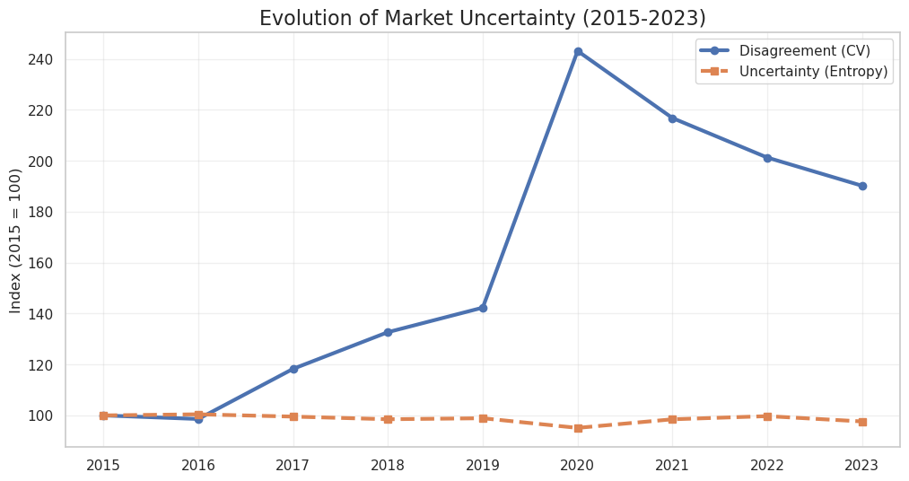

```python
# Calculate the yearly avg for the CV and entropy
yearly_avg = firm_level_data_cleaned.groupby('fiscal_year')[['revenue_cv', 'revenue_entropy']].mean().reset_index()

plt.figure(figsize=(12, 6))
# Normalize to start at 100
yearly_avg['cv_index'] = yearly_avg['revenue_cv'] / yearly_avg['revenue_cv'].iloc[0] * 100
yearly_avg['ent_index'] = yearly_avg['revenue_entropy'] / yearly_avg['revenue_entropy'].iloc[0] * 100

plt.plot(yearly_avg['fiscal_year'], yearly_avg['cv_index'], marker='o', label='Disagreement (CV)', linewidth=3)
plt.plot(yearly_avg['fiscal_year'], yearly_avg['ent_index'], marker='s', label='Uncertainty (Entropy)', linewidth=3, linestyle='--')
plt.title('Evolution of Market Uncertainty (2015-2023)', fontsize=16)
plt.ylabel('Index (2015 = 100)')
plt.legend()
plt.grid(True, alpha=0.3)
plt.show()
```

### 2.3. Sector Breakdown

#### 2.3.1. Boxplots

To examine whether analyst disagreement varies across industries, we plot the transformed coefficient of variation (revenue_cv_yj) by sector. The boxplots show meaningful cross-sector differences: sectors such as Health Care and Energy exhibit higher and more dispersed disagreement (in these industries revenue targets are highly dependent things like FDA approval which can make or break the analyst estimates), while Consumer Staples and Telecommunication Services show more tightly clustered estimates. This confirms that the distributional shape of analyst forecasts is not uniform across industries, reinforcing the importance of using normalized, relative disagreement metrics in our analysis.

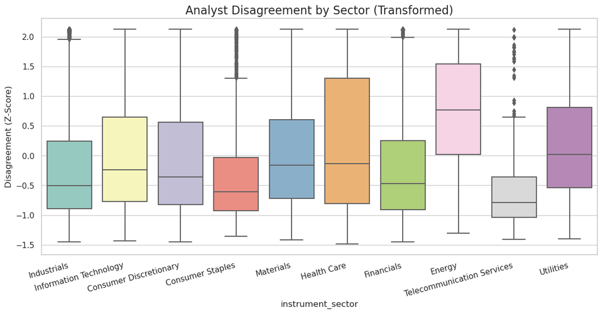

```python
plt.figure(figsize=(14, 6))
sns.boxplot(x='instrument_sector', y='revenue_cv_yj', data=firm_level_data_cleaned, palette="Set3")
plt.title('Analyst Disagreement by Sector (Transformed)', fontsize=16)
plt.xticks(rotation=15, ha='right')
plt.ylabel('Disagreement (Z-Score)')
plt.show()
```

#### 2.3.2. Bar Chart

Consistent with the boxplot results, the bar chart shows clear cross-sector differences in analyst disagreement. Energy and Health Care exhibit the highest average coefficients of variation, indicating that revenues in these industries are more difficult to forecast. By contrast, Consumer Staples and Telecommunications show the lowest disagreement. These patterns confirm that prediction difficulty varies across sectors.

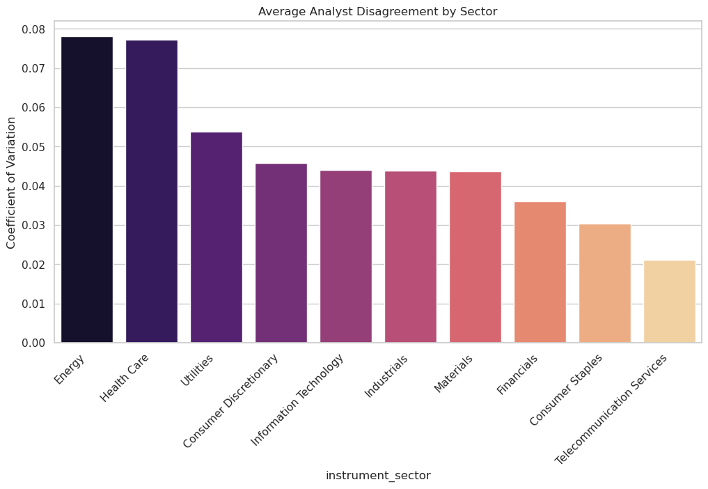

```python
plt.figure(figsize=(12, 6))
avg_cv = firm_level_data_cleaned.groupby('instrument_sector')['revenue_cv'].mean().sort_values(ascending=False)
sns.barplot(x=avg_cv.index, y=avg_cv.values, palette='magma')
plt.xticks(rotation=45, ha='right')
plt.title('Average Analyst Disagreement by Sector')
plt.ylabel('Coefficient of Variation')
plt.show()
```

#### Average Skewness for each sector

This graph shows us that most sectors are very neurtally skewed and their distributions are very similar as well. The utilies sector seems to be very tighly bound as compared to the other sector.

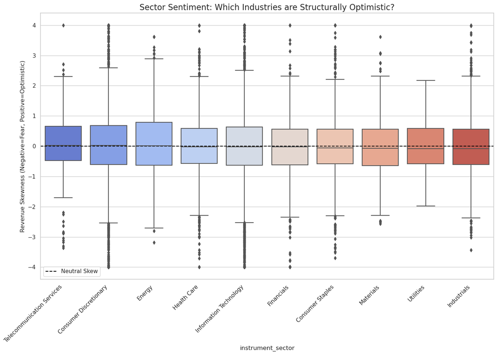

```python
plt.figure(figsize=(14, 10))

# Sort sectors by Median Skew so the graph flows nicely (Bullish -> Bearish)
sorted_sectors = firm_level_data_cleaned.groupby('instrument_sector')['revenue_skew_yj'].median().sort_values(ascending=False).index

sns.boxplot(
    x='instrument_sector',
    y='revenue_skew_yj',
    data=firm_level_data_cleaned,
    order=sorted_sectors,
    palette='coolwarm' # Red = Bullish, Blue = Bearish
)

# Add Reference Line at 0 (Neutral)
plt.axhline(0, color='black', linestyle='--', linewidth=1.5, label='Neutral Skew')

plt.xticks(rotation=45, ha='right')
plt.title('Sector Sentiment: Which Industries are Structurally Optimistic?', fontsize=16)
plt.ylabel('Revenue Skewness (Negative=Fear, Positive=Optimistic)')
plt.legend()
plt.tight_layout()
plt.show()
```

### 2.4. Disagreement vs Volatility

This is visualisation of the hypothesis and we can clearly see the relation well.

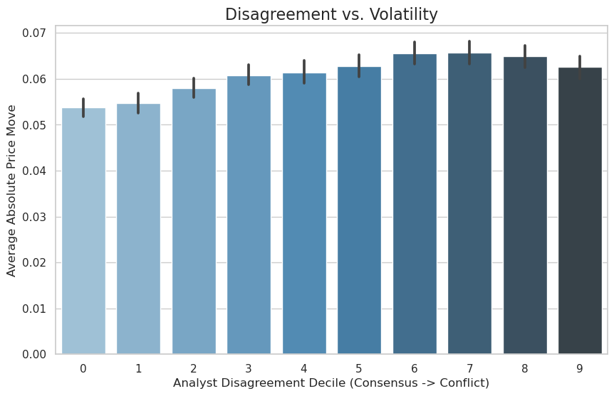

```python
firm_level_data_cleaned['cv_decile'] = pd.qcut(firm_level_data_cleaned['revenue_cv'], 10, labels=False)

plt.figure(figsize=(10, 6))
sns.barplot(x='cv_decile', y='abs_return', data=firm_level_data_cleaned, palette="Blues_d")
plt.title('Disagreement vs. Volatility', fontsize=16)
plt.xlabel('Analyst Disagreement Decile (Consensus -> Conflict)')
plt.ylabel('Average Absolute Price Move')
plt.show()
```

### 2.5. Skewness vs Volatility

Here, we are checking whether skewness (bullish or bearish) affects price movement. Our intuition told us that when analysts have negative skew (bearish) we would expect more price movement.

However, we notice something very interesting, we see volatility (abs price return) increase with skewness very consistently. This suggests that as a bullish skew makes the stock more volatile.

After careful thought we realise that this makes sense, as the market would price in the bad news well and even a good revenue will not move the market (as seen very recently with the NVIDIA results). However, if there is a bullish skew -

- If the company beats estimates the stock would rise very fast
- If the company underperforms, more often than not we will see a sharp decline in stock price.

This leads us to test another hypothesis later on whether this effect is statistically significant

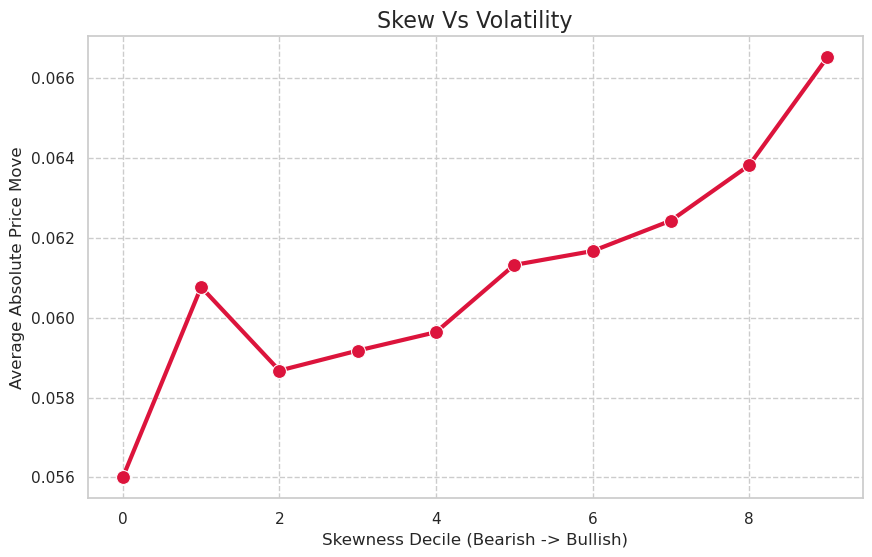

```python
firm_level_data_cleaned['skew_decile'] = pd.qcut(firm_level_data_cleaned['revenue_skew_yj'], 10, labels=False)

plt.figure(figsize=(10, 6))
sns.lineplot(
    x='skew_decile', y='abs_return', data=firm_level_data_cleaned,
    marker='o', color='crimson', linewidth=3, ci = None, markersize = 10
)
plt.title('Skew Vs Volatility', fontsize=16)
plt.xlabel('Skewness Decile (Bearish -> Bullish)')
plt.ylabel('Average Absolute Price Move')
plt.grid(True, linestyle='--')
plt.show()
```

## 3. PCA

We use PCA to build features for our regression model which would utilise a combination of shape of the distributions that we have cleaned up till now. We apply principal component analysis (PCA) to the transformed “shape” variables: revenue_cv_yj, revenue_entropy_yj, revenue_skew_yj, and revenue_kurt_yj. We start with all four components to see the variance explained by individual components and the cumulative variance explained.

According to the scree plot, the first two principal components explain about 47% and 24% of the variance respectively (≈70% cumulatively), with the remaining components each contributing much less. Therefore, we keep the top two components for subsequent analysis.

The loading heatmap shows how strongly each original forecast-shape feature contributes to each principal component (PC1 and PC2). Each number is a loading (correlation-like coefficient), and the color indicates whether the feature pushes the component positively (blue) or negatively (red).

PC1 is driven by dispersion-related features (CV, kurtosis, entropy), forming an “uncertainty” factor, while PC2 is almost entirely explained by skewness, forming an “asymmetry” factor. This confirms the data distribution and feature vectors seen in the Biplot.

```
Explained Variance Ratio per Component:
PC1: 46.86% (Cumulative: 46.86%)
PC2: 23.63% (Cumulative: 70.49%)
PC3: 18.04% (Cumulative: 88.53%)
PC4: 11.47% (Cumulative: 100.00%)
```

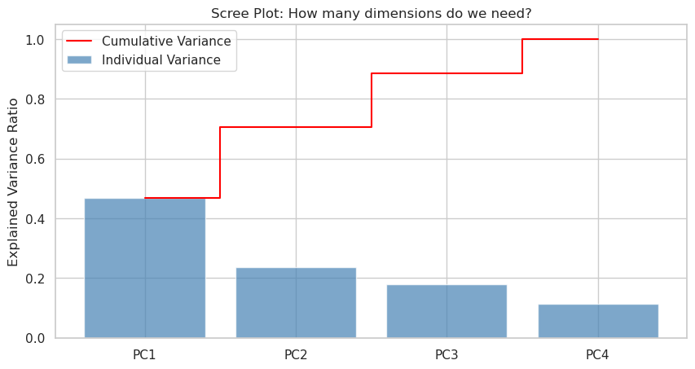

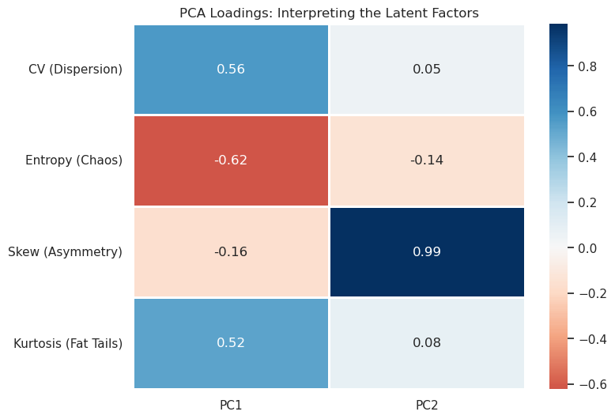

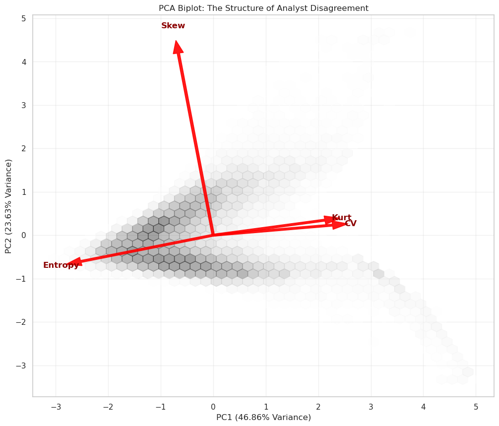

```python
# Select the Transformed Shape Features
shape_features = ['revenue_cv_yj', 'revenue_entropy_yj', 'revenue_skew_yj', 'revenue_kurt_yj']
X_shape = firm_level_data_cleaned[shape_features]

# Fit PCA
pca_full = PCA(n_components=4)
pca_full.fit(X_shape)

# Analyze Variance Explained (The Scree Plot)
evr = pca_full.explained_variance_ratio_
cumulative_variance = np.cumsum(evr)

print("Explained Variance Ratio per Component:")
for i, var in enumerate(evr):
    print(f"PC{i+1}: {var:.2%} (Cumulative: {cumulative_variance[i]:.2%})")

# We keep top 2 Components for visualization/regression
pca = PCA(n_components=2)
pca_components = pca.fit_transform(X_shape)

# Save Scores to DataFrame
firm_level_data_cleaned['PC1_Uncertainty'] = pca_components[:, 0]
firm_level_data_cleaned['PC2_Asymmetry'] = pca_components[:, 1]

# VISUALISATION FOR PCA
# The Scree Plot
plt.figure(figsize=(10, 5))
x_labels = ['PC1', 'PC2', 'PC3', 'PC4']
plt.bar(x_labels, evr, alpha=0.7, color='steelblue', label='Individual Variance')
plt.step(x_labels, cumulative_variance, where='mid', color='red', label='Cumulative Variance')
plt.ylabel('Explained Variance Ratio')
plt.title('Scree Plot: How many dimensions do we need?')
plt.legend()
plt.show()

# The Loadings Heatmap, This explains what PC1 and PC2 actually measure.
loadings = pd.DataFrame(
    pca.components_.T,
    columns=['PC1', 'PC2'],
    index=['CV (Dispersion)', 'Entropy (Chaos)', 'Skew (Asymmetry)', 'Kurtosis (Fat Tails)']
)

plt.figure(figsize=(8, 6))
sns.heatmap(loadings, annot=True, cmap='RdBu', center=0, fmt='.2f', linewidths=1)
plt.title('PCA Loadings: Interpreting the Latent Factors')
plt.show()

# The Biplot that shows both the data distribution and the feature vectors
def biplot(score, coeff, labels=None):
    plt.figure(figsize=(12, 10))
    xs = score[:, 0]
    ys = score[:, 1]

    # Using hexbin for density since we have 40k points (Scatter is too messy)
    plt.hexbin(xs, ys, gridsize=40, cmap='Greys', mincnt=1, alpha=0.4)

    # Plot Arrows (Feature Vectors)
    n = coeff.shape[0]
    # Scaling factor to make arrows visible over the data spread
    scale_x = (xs.max() - xs.min()) / (coeff[:,0].max() - coeff[:,0].min()) * 0.6
    scale_y = (ys.max() - ys.min()) / (coeff[:,1].max() - coeff[:,1].min()) * 0.6

    for i in range(n):
        plt.arrow(0, 0, coeff[i,0]*scale_x, coeff[i,1]*scale_y, color='red', alpha=0.9, width=0.05, head_width=0.2)
        plt.text(coeff[i,0]*scale_x*1.15, coeff[i,1]*scale_y*1.15, labels[i], color='darkred', ha='center', va='center', weight='bold', fontsize=12)

    plt.xlabel(f"PC1 ({evr[0]:.2%} Variance)")
    plt.ylabel(f"PC2 ({evr[1]:.2%} Variance)")
    plt.title("PCA Biplot: The Structure of Analyst Disagreement")
    plt.grid(True, alpha=0.3)
    plt.show()

biplot(pca_components, pca.components_.T, labels=['CV', 'Entropy', 'Skew', 'Kurt'])
```

## 4. K Means Clustering

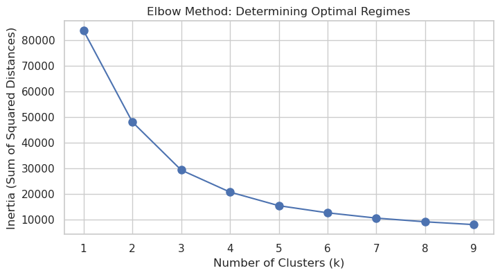

```python
X_pca = firm_level_data_cleaned[['PC1_Uncertainty', 'PC2_Asymmetry']]

# FIND OPTIMAL CLUSTERS (The Elbow Method)
inertia = []
K_range = range(1, 10)

for k in K_range:
    kmeans = KMeans(n_clusters=k, random_state=42, n_init=10)
    kmeans.fit(X_pca)
    inertia.append(kmeans.inertia_)

# The Elbow Plot
plt.figure(figsize=(8, 4))
plt.plot(K_range, inertia, 'bo-', markersize=8)
plt.xlabel('Number of Clusters (k)')
plt.ylabel('Inertia (Sum of Squared Distances)')
plt.title('Elbow Method: Determining Optimal Regimes')
plt.grid(True)
plt.show()
```

The Elbow Plot is used for determining the number of clusters.

We choose 3 clusters (this is a bit arbitrary, we could have also chosen 4 or 5) since the inertia drops the most at these 3 points.

We chose 3 clusters as we think they represent the analysts pretty well namely -

- Consensus (Low Risk),
- Confusion (High Risk), and
- Structural Disagreement.

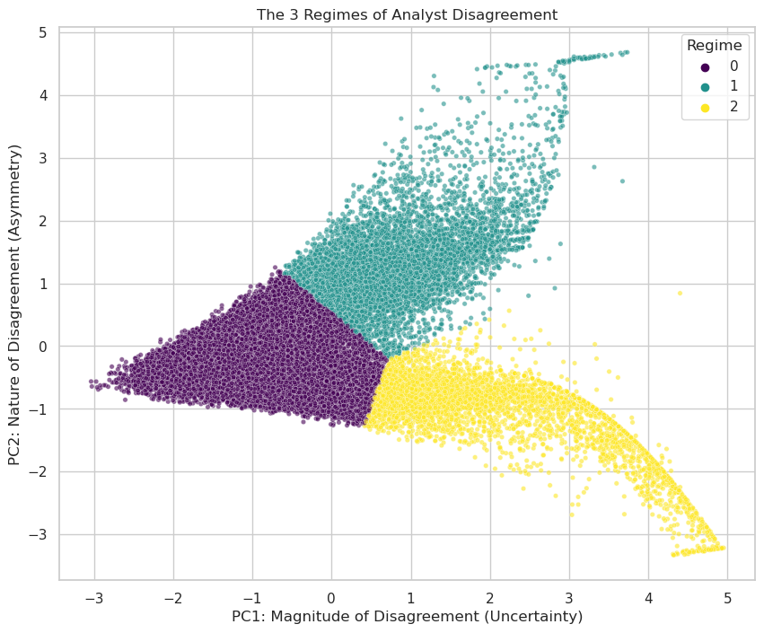

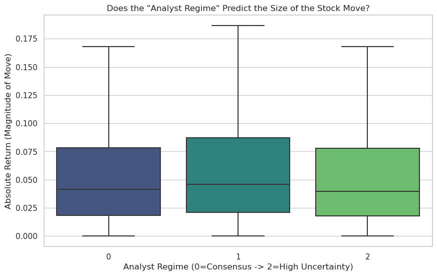

```
Mean Absolute Return by Cluster:
```

```
Cluster_Sorted
0   0.05953
1   0.06628
2   0.05917
Name: abs_return, dtype: float64
```

```python
# RUN CLUSTERING (k=3)
kmeans = KMeans(n_clusters=3, random_state=42, n_init=10)
firm_level_data_cleaned['Cluster'] = kmeans.fit_predict(X_pca)

# Sort clusters by Mean Uncertainty (PC1)
# This ensures Cluster 0 is always "Low Uncertainty" and Cluster 2 is "High Uncertainty" (to be consistent)
cluster_mapping = firm_level_data_cleaned.groupby('Cluster')['PC1_Uncertainty'].mean().sort_values().index
mapper = {old: new for new, old in enumerate(cluster_mapping)}
firm_level_data_cleaned['Cluster_Sorted'] = firm_level_data_cleaned['Cluster'].map(mapper)

# VISUALISE THE REGIMES
# The Clusters in PCA Space
plt.figure(figsize=(10, 8))
sns.scatterplot(x='PC1_Uncertainty', y='PC2_Asymmetry', hue='Cluster_Sorted',
                data=firm_level_data_cleaned, palette='viridis', alpha=0.6, s=15)
plt.title('The 3 Regimes of Analyst Disagreement')
plt.xlabel('PC1: Magnitude of Disagreement (Uncertainty)')
plt.ylabel('PC2: Nature of Disagreement (Asymmetry)')
plt.legend(title='Regime')
plt.show()

# The Payoff (Do Clusters predict Volatility?)
plt.figure(figsize=(10, 6))
sns.boxplot(x='Cluster_Sorted', y='abs_return', data=firm_level_data_cleaned, palette='viridis', showfliers=False)
plt.title('Does the "Analyst Regime" Predict the Size of the Stock Move?')
plt.xlabel('Analyst Regime (0=Consensus -> 2=High Uncertainty)')
plt.ylabel('Absolute Return (Magnitude of Move)')
plt.show()

pd.set_option('display.float_format', lambda x: '%.5f' % x)
# Print Statistics to verify significance
print("Mean Absolute Return by Cluster:")
firm_level_data_cleaned.groupby('Cluster_Sorted')['abs_return'].mean()
```

#### The Regimes Scatterplot - This defines who is in each cluster.

- Purple (Cluster 0): Low PC1 (Left side) this is the "The Consensus Regime." Analysts agree (Low CV) and are confident (Low Entropy).
- Teal (Cluster 1): High PC1 (Right) + High PC2 (Top) this is the "High Uncertainty Shape." Analysts are confused, and the distribution shape is pulling in one direction (likely Positive Skew/Kurtosis).
- Yellow (Cluster 2): High PC1 (Right) + Low PC2 (Bottom) this is the "High Uncertainty Shape B" Analysts are confused, but the shape is pulling in the opposite direction (likely Negative Skew).

Uncertainty isn't just one thing. When analysts disagree, they split into two distinct structural shapes (Teal vs. Yellow).

#### The Boxplot

- Cluster 0 (Consensus) is the baseline. It has the lowest median (the line inside the box) and the tightest Interquartile Range (the height of the box).
- Cluster 1 (Teal) is the most volatile. It is shifted higher than Cluster 0. This suggests that when analysts disagree in this specific way (High PC2), the stock moves significantly more.
- Cluster 2 (Yellow) also represents High Uncertainty (High PC1), however its returns are similar to the Consensus group. But given our EDA above we can hypotheize that this might be the negative skew which causes less price movement

Not all Disagreement is created equal."Disagreement Type 1 (Teal) to Higher Price Moves whereas Disagreement Type 2 (Yellow) to No extra Price Move.

## 5. Linear Regression and Random Forest (Modeling)

To evaluate how well analyst forecast shape metrics explain the magnitude of price moves following the announcement, we run both linear (Linear Regression) and non-linear predictive models (Random Fores) using the transformed CV, skewness, kurtosis, and entropy features.

We train the models on an 80/20 split and examine out-of-sample R² as an indicator of signal strength. A random forest model is included to capture potential non-linear relationships that a linear regression might miss, and we extract feature importance scores to understand which components of analyst disagreement matter most.

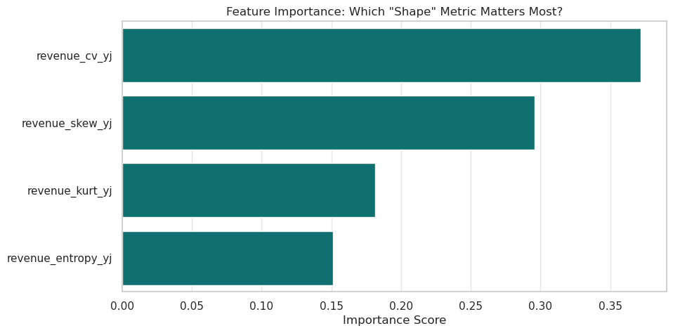

```
-----------------------------------
Linear Regression R2: 0.00521
Decision Tree (RF) R2: 0.00734
-----------------------------------
Non-Linear Improvement: 1.4x
-----------------------------------
```

```python
# Define Predictors (X) and Target (y)
features = ['revenue_cv_yj', 'revenue_skew_yj', 'revenue_kurt_yj', 'revenue_entropy_yj']
X = firm_level_data_cleaned[features]
y = firm_level_data_cleaned['abs_return']

# Train/Test Split, We hide 20% of the data to test if the model actually works on unseen stocks (learnt from ML1)
X_train, X_test, y_train, y_test = train_test_split(X, y, test_size=0.2, random_state=42)

# Train Linear Regression
lin_reg = LinearRegression()
lin_reg.fit(X_train, y_train)
y_pred_lin = lin_reg.predict(X_test)
r2_lin = r2_score(y_test, y_pred_lin)

# Train Random Forest (The Non-Linear Approach)
# We use Random Forest because it is more robust than a single Decision Tree (and suggested by Prof. Yurko)
rf_reg = RandomForestRegressor(n_estimators=100, max_depth=5, random_state=42)
rf_reg.fit(X_train, y_train)
y_pred_rf = rf_reg.predict(X_test)
r2_rf = r2_score(y_test, y_pred_rf)

# Extract Feature Importance
importances = pd.DataFrame({
    'Feature': features,
    'Importance': rf_reg.feature_importances_
}).sort_values(by='Importance', ascending=False)

# VISUALISATION: FEATURE IMPORTANCE
plt.figure(figsize=(10, 5))
sns.barplot(x='Importance', y='Feature', data=importances, color='teal')
plt.title('Feature Importance: Which "Shape" Metric Matters Most?')
plt.xlabel('Importance Score')
plt.ylabel('')
plt.grid(axis='x', alpha=0.5)
plt.show()

# The Comparison
if r2_lin > 0:
    improvement = r2_rf / r2_lin
    imp_str = f"{improvement:.1f}x"
else:
    imp_str = "N/A (Linear R2 is negative)"

print("-" * 35)
print(f"Linear Regression R2: {r2_lin:.5f}")
print(f"Decision Tree (RF) R2: {r2_rf:.5f}")
print("-" * 35)
print(f"Non-Linear Improvement: {imp_str}")
print("-" * 35)
```

INTERPRETATION of these models:

The Non-Linear model outperforms the Linear model. This suggests that the relationship between Analyst Disagreement and Stock Volatility is complex (not a straight line). (however, given the abysmal R2, it is possible we need more variables)

The most important predictor is revenue_cv_yj as seen from the feature importance plot. This is expected as we were testing for this and seen in the plots above

## 6. How does R2 change when we only look at companies with high number of analysts

To test whether our findings are driven by noisy analyst estimates in thinly covered firms, we repeat the regression analysis on a much narrower subset of “high-visibility” stocks—those with at least 100 analyst revenue forecasts.

```
Analyzing 854 'High Visibility' stocks (N >= 100)...

--- RESULTS: HIGH VISIBILITY SUBSET (N >= 100) ---
1. Linear Regression R2:  0.04260
2. Random Forest R2:      0.07553

Non-Linear Model Advantage: 77.3% improvement
```

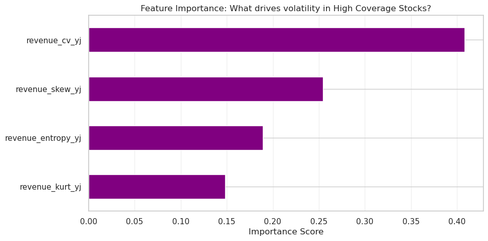

```python
# Filter for High Visibility Stocks
high_analyst_df = firm_level_data_cleaned[firm_level_data_cleaned['revenue_count'] >= 100].copy()

features = ['revenue_cv_yj', 'revenue_skew_yj', 'revenue_kurt_yj', 'revenue_entropy_yj']
X = high_analyst_df[features]
y = high_analyst_df['abs_return']

print(f"Analyzing {len(high_analyst_df)} 'High Visibility' stocks (N >= 100)...")

# Train/Test Split
X_train, X_test, y_train, y_test = train_test_split(X, y, test_size=0.2, random_state=42)

# Run Linear Regression (The Baseline)
lin_reg = LinearRegression()
lin_reg.fit(X_train, y_train)
y_pred_lin = lin_reg.predict(X_test)
r2_lin = r2_score(y_test, y_pred_lin)

# Run Random Forest (The Non-Linear Model)
rf_reg = RandomForestRegressor(n_estimators=100, max_depth=5, random_state=42)
rf_reg.fit(X_train, y_train)
y_pred_rf = rf_reg.predict(X_test)
r2_rf = r2_score(y_test, y_pred_rf)

# Results & "Non-Linearity Premium"
print("\n--- RESULTS: HIGH VISIBILITY SUBSET (N >= 100) ---")
print(f"1. Linear Regression R2:  {r2_lin:.5f}")
print(f"2. Random Forest R2:      {r2_rf:.5f}")

if r2_lin > 0.0001:
    gain = (r2_rf - r2_lin) / r2_lin
    print(f"\nNon-Linear Model Advantage: {gain:.1%} improvement")
else:
    print("\nNon-Linear Model Advantage: Infinite (Linear model failed to capture signal)")

# Feature Importance Plot
importances = pd.Series(rf_reg.feature_importances_, index=features).sort_values(ascending=True)

plt.figure(figsize=(10, 5))
importances.plot(kind='barh', color='#800080')
plt.title('Feature Importance: What drives volatility in High Coverage Stocks?')
plt.xlabel('Importance Score')
plt.grid(axis='x', alpha=0.3)
plt.show()
```

The R² values are still small, but they are substantially higher than in the previous full-sample regressions. When more analysts cover a stock (N ≥ 100), the shape metrics become more informative about volatility. In the previous importance score, CV was the top feature; In this high-coverage example, it remains the top feature with a higher importance score. This indicates that when analyst estimates are reliable (high number of analysis), disagreement(CV) becomes the clearest predictor of volatility.

## 7. Hypothesis Test to check whether analyst disagreement leads to more price movement

We now do a hypothesis test and move away from regression because there are a lot of other factors going into prediction of stock prices. We try to isolate the whether analyst disagreement causes price movement.

We will compare the top 20% and the bottom 20% of revenue_cv_yj variable to see the bottom and top 2 deciles. This removes the noisy middle 60% where the signal is weak.

While the linear regression R2 is low, the statistical significance of the signal is very clear. A T-test confirms that stocks in the top quintile of analyst disagreement experience significantly higher volatility than those in the bottom quintile (p < 0.001). This confirms that Disagreement is a robust risk factor, even if day-to-day noise makes precise prediction difficult.

```
Sample Sizes:
High Disagreement Group: 6027
Low Disagreement Group:  6027

--- HYPOTHESIS TEST: DISAGREEMENT ---
High Disagreement Avg Volatility: 0.0637
Low Disagreement Avg Volatility:  0.0542
Difference:                       +17.5% higher
----------------------------------------
T-Statistic: 8.3006
P-Value:     1.1498e-16
```

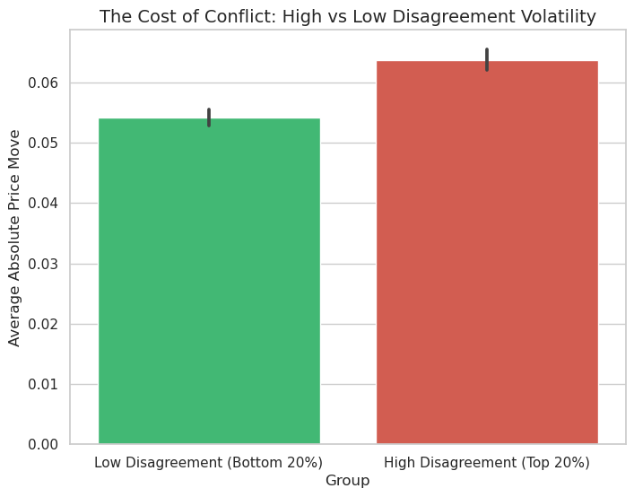

```python
# We compare the Top 20% (High Conflict) vs Bottom 20% (Consensus)
upper_cutoff = firm_level_data_cleaned['revenue_cv_yj'].quantile(0.80)
lower_cutoff = firm_level_data_cleaned['revenue_cv_yj'].quantile(0.20)

# Create the groups
high_disagreement = firm_level_data_cleaned[firm_level_data_cleaned['revenue_cv_yj'] >= upper_cutoff]['abs_return']
low_disagreement = firm_level_data_cleaned[firm_level_data_cleaned['revenue_cv_yj'] <= lower_cutoff]['abs_return']

print(f"Sample Sizes:")
print(f"High Disagreement Group: {len(high_disagreement)}")
print(f"Low Disagreement Group:  {len(low_disagreement)}")

# THE T-TEST
t_stat, p_val = stats.ttest_ind(high_disagreement, low_disagreement, equal_var=False)

print("\n--- HYPOTHESIS TEST: DISAGREEMENT ---")
print(f"High Disagreement Avg Volatility: {high_disagreement.mean():.4f}")
print(f"Low Disagreement Avg Volatility:  {low_disagreement.mean():.4f}")
print(f"Difference:                       +{high_disagreement.mean() / low_disagreement.mean() - 1:.1%} higher")
print("-" * 40)
print(f"T-Statistic: {t_stat:.4f}")
print(f"P-Value:     {p_val:.4e}")

# VISUALIZATION A simple boxplot to show the difference visually
plt.figure(figsize=(8, 6))
plot_data = pd.concat([
    pd.DataFrame({'Group': 'Low Disagreement (Bottom 20%)', 'Volatility': low_disagreement}),
    pd.DataFrame({'Group': 'High Disagreement (Top 20%)', 'Volatility': high_disagreement})
])

sns.barplot(x='Group', y='Volatility', data=plot_data, palette=['#2ecc71', '#e74c3c'])
plt.title('The Cost of Conflict: High vs Low Disagreement Volatility', fontsize=14)
plt.ylabel('Average Absolute Price Move')
plt.show()
```

# Hypothesis 2: Does the direction of the uncertainty matter?

## 1. Overview

### 1.1 Rationale

The "Shape" of the analyst distribution is not defined solely by its width (Disagreement) but also by its direction (Skewness). In the context of our analysis, negative skew of revenue (longer left Tail) indicates that most analysts are bullish, but a few "bears" expect a disaster. Positive Skew (longer right Tail) indicates that Most analysts are bearish, but a few "bulls" expect a moonshot.

We tested two competing behavioral finance hypotheses regarding how this asymmetry affects market risk:

- Hypothesis A (Loss Aversion): Investors feel the pain of a loss more acutely than the joy of a gain. Therefore, stocks with Negative Skew (where a "Long Left Tail" of analysts predicts a significant revenue miss) should generate higher anxiety and volatility.
- Hypothesis B (The Lottery Ticket Effect): Investors are attracted to assets with high speculative upside. Stocks with Positive Skew (where a "Long Right Tail" of analysts predicts a massive beat) attract speculative capital, creating a "gambling premium" that exacerbates volatility.

### 1.2 Financial Intuition

From a loss-aversion perspective, markets fear downside surprises more than they value upside ones. Thus, Negative Skew should predict higher volatility, as investors react more strongly to the risk of adverse outcomes than to optimistic scenarios.

### 1.3 Testing Methodology

We will check if the relationship between revenue_skew and abs_return is U-shaped (The "Smile", direction is not significant) or J-shaped (Downside fear is stronger).

### 1.4 Data Processing

We will only look at those obs which have more than 5 analyst rating since only they had a natural skew, and also winsorize extreme outliers (out of [-3,3]), so they don't overly influence regressions or plots. Then we take each stock’s revenue_skew and subtracts the median skew of its sector to create the relative skew within industry.

Using the processed data described above, we rank stocks into 10 buckets based on their relative skew. To adjudicate between these hypotheses, we categorized stocks into three sentiment regimes:

- Negative Skew (Bearish)
- Neutral (Symmetric)
- Positive Skew (Bullish)

```python
# We use only stocks with >= 5 analysts to ensure Skewness is mathematically valid.
high_fidelity_df = firm_level_data_cleaned[firm_level_data_cleaned['revenue_count'] >= 5].copy()

# Winsorize extreme skew outliers (just for this specific analysis)
high_fidelity_df['revenue_skew'] = high_fidelity_df['revenue_skew'].clip(-3, 3)

# CALCULATE INDUSTRY-RELATIVE SKEW
# "Is this stock more skewed than its peers?"
sector_median_skew = high_fidelity_df.groupby('instrument_sector')['revenue_skew'].transform('median')
high_fidelity_df['relative_skew'] = high_fidelity_df['revenue_skew'] - sector_median_skew

# CREATE BUCKETS & DECILES
high_fidelity_df['rel_skew_decile'] = pd.qcut(high_fidelity_df['relative_skew'], 10, labels=False)

# Sentiment Buckets for the T-Test
conditions_rel = [
    (high_fidelity_df['relative_skew'] < -0.5),
    (high_fidelity_df['relative_skew'] >= -0.5) & (high_fidelity_df['relative_skew'] <= 0.5),
    (high_fidelity_df['relative_skew'] > 0.5)
]
choices_rel = ['Relatively Bearish', 'Sector Neutral', 'Relatively Bullish']
high_fidelity_df['Relative_Skew_Category'] = np.select(conditions_rel, choices_rel, default='Sector Neutral')

print("Observation Counts per Category:")
print(high_fidelity_df['Relative_Skew_Category'].value_counts())
```

```
Observation Counts per Category:
Relatively Bearish    12025
Relatively Bullish    11841
Sector Neutral         6269
Name: Relative_Skew_Category, dtype: int64
```

## 2. Analysis and Results

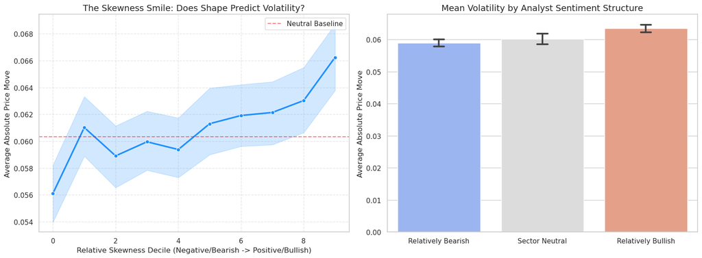

```
--- Hypothesis Test Results ---
1. Bullish Skew (Hope) vs Neutral: P-Value = 2.0228e-03 (T-Stat: 3.09)
2. Bearish Skew (Fear) vs Neutral: P-Value = 2.1978e-01 (T-Stat: -1.23)
```

```python
# VISUALIZATION
fig, ax = plt.subplots(1, 2, figsize=(16, 6))

# The J-Curve (Skew vs abs return)
sns.lineplot(
    x='rel_skew_decile', y='abs_return', data=high_fidelity_df,
    marker='o', color='dodgerblue', linewidth=2.5, ax=ax[0]
)
# Add a baseline (Mean of the middle deciles) for comparison
baseline = high_fidelity_df[high_fidelity_df['rel_skew_decile'].isin([4, 5])]['abs_return'].mean()
ax[0].axhline(baseline, color='red', linestyle='--', alpha=0.5, label='Neutral Baseline')

ax[0].set_title('The Skewness Smile: Does Shape Predict Volatility?', fontsize=14)
ax[0].set_xlabel('Relative Skewness Decile (Negative/Bearish -> Positive/Bullish)')
ax[0].set_ylabel('Average Absolute Price Move')
ax[0].legend()
ax[0].grid(True, linestyle='--', alpha=0.5)

# Sentiment Comparison (Bar Chart)
order_rel = ['Relatively Bearish', 'Sector Neutral', 'Relatively Bullish']
sns.barplot(
    x='Relative_Skew_Category', y='abs_return', data=high_fidelity_df,
    order=order_rel, palette="coolwarm", capsize=0.1, ax=ax[1]
)
ax[1].set_title('Mean Volatility by Analyst Sentiment Structure', fontsize=14)
ax[1].set_ylabel('Average Absolute Price Move')
ax[1].set_xlabel('')

plt.tight_layout()
plt.show()

# STATISTICAL CONFIRMATION
# T-Test: Is Skewed Sentiment significantly riskier than Neutral?
bullish_vol = high_fidelity_df[high_fidelity_df['Relative_Skew_Category'] == 'Relatively Bullish']['abs_return']
neutral_vol = high_fidelity_df[high_fidelity_df['Relative_Skew_Category'] == 'Sector Neutral']['abs_return']
bearish_vol = high_fidelity_df[high_fidelity_df['Relative_Skew_Category'] == 'Relatively Bearish']['abs_return']

t_stat_bull, p_val_bull = stats.ttest_ind(bullish_vol, neutral_vol, equal_var=False)
t_stat_bear, p_val_bear = stats.ttest_ind(bearish_vol, neutral_vol, equal_var=False)

print("\n--- Hypothesis Test Results ---")
print(f"1. Bullish Skew (Hope) vs Neutral: P-Value = {p_val_bull:.4e} (T-Stat: {t_stat_bull:.2f})")
print(f"2. Bearish Skew (Fear) vs Neutral: P-Value = {p_val_bear:.4e} (T-Stat: {t_stat_bear:.2f})")
```

From the relative skewness vs. absolute price move plot, using the mean of the middle deciles as baseline, the relatively negative skew (within its industry) shows smaller absolute price move compared to baseline and the bullish skew. The second plot categorizes the absolute price movement by categories, which confirms our conclusion from the first plot by comparing the mean volatility.

To gather more rigorous statistical evidence, we performed independent T-tests to compare the volatility of the skewed groups against the neutral control group.

- Negative Skew vs. Neutral: $T\text{-Statistic}: -1.23$; $P\text{-Value}: 0.2197$ (Not Significant)
  - Result: There is no statistical difference in risk between stocks with downside fears and neutral stocks.
- Positive Skew vs. Neutral: $T\text{-Statistic}: 3.09 $; $P\text{-Value}: 2.0228 \times 10^{-3}$ (Highly Significant)
  - Result: Stocks with upside speculative potential experience significantly higher volatility.

Our analysis rejects the Loss Aversion hypothesis in the context of earnings announcements and supports the Lottery Ticket Hypothesis. The data suggests that "Fear" (Negative Skew) is efficiently priced into the stock before the announcement; when the bad news arrives, the market reaction is muted because it was expected. In contrast, "Hope" (Positive Skew) creates instability. A positively skewed distribution implies a small probability of a massive fundamental beat. This attracts speculative trading activity.

- Scenario A (Beat): The speculation is validated, and the price surges.
- Scenario B (Miss): The speculative premium collapses, and the price crashes.

## Hypothesis 3: The False Consensus Shock (The Black Swan Theory)

We have been assuming that High Disagreement causes the biggest moves. But what if the most dangerous state is actually Low Disagreement (High Consensus) followed by a Surprise?

If all analysts agree (Low CV, Low Entropy), the market "prices in" that specific outcome with high confidence. If the company then misses that target, the re-pricing should be violent because the market was caught off guard.

Is a "Surprise" more damaging when Analyst Consensus was strong (Low Disagreement) versus when Analyst Consensus was weak (High Disagreement)?

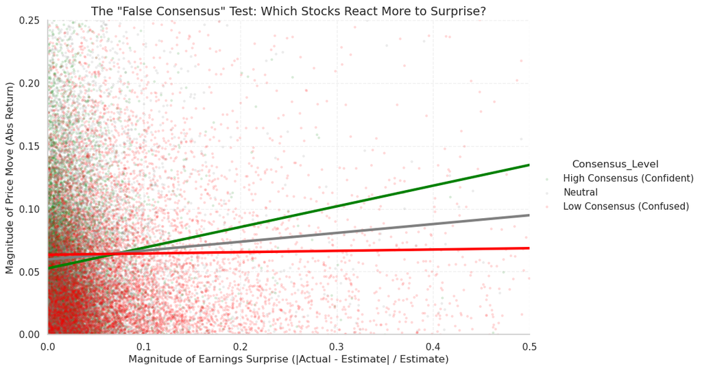

```
--- Interaction Regression Results ---
                            OLS Regression Results
==============================================================================
Dep. Variable:             abs_return   R-squared:                       0.006
Model:                            OLS   Adj. R-squared:                  0.006
Method:                 Least Squares   F-statistic:                     38.62
Date:                Wed, 03 Dec 2025   Prob (F-statistic):           1.14e-39
Time:                        21:29:49   Log-Likelihood:                 39688.
No. Observations:               30135   AIC:                        -7.936e+04
Df Residuals:                   30129   BIC:                        -7.931e+04
Df Model:                           5
Covariance Type:            nonrobust
===============================================================================================================================
                                                                  coef    std err          t      P>|t|      [0.025      0.975]
-------------------------------------------------------------------------------------------------------------------------------
Intercept                                                       0.0526      0.001     67.894      0.000       0.051       0.054
C(Consensus_Level)[T.Neutral]                                   0.0071      0.001      6.308      0.000       0.005       0.009
C(Consensus_Level)[T.Low Consensus (Confused)]                  0.0108      0.001      9.869      0.000       0.009       0.013
abs_surprise                                                    0.1646      0.019      8.764      0.000       0.128       0.201
abs_surprise:C(Consensus_Level)[T.Neutral]                     -0.0942      0.023     -4.046      0.000      -0.140      -0.049
abs_surprise:C(Consensus_Level)[T.Low Consensus (Confused)]    -0.1541      0.019     -7.986      0.000      -0.192      -0.116
==============================================================================
Omnibus:                    21728.784   Durbin-Watson:                   1.913
Prob(Omnibus):                  0.000   Jarque-Bera (JB):           626492.847
Skew:                           3.144   Prob(JB):                         0.00
Kurtosis:                      24.434   Cond. No.                         101.
==============================================================================

Notes:
[1] Standard Errors assume that the covariance matrix of the errors is correctly specified.
```

```python
# We use the cleaned dataset
df_hypo1 = firm_level_data_cleaned.copy()

# We split the data into 3 buckets based on Disagreement (CV)
# Low CV = "High Consensus" (Analysts Agree)
# High CV = "Low Consensus" (Analysts Disagree)
df_hypo1['Consensus_Level'] = pd.qcut(
    df_hypo1['revenue_cv_yj'],
    q=3,
    labels=['High Consensus (Confident)', 'Neutral', 'Low Consensus (Confused)']
)

# The "Sensitivity" Plot, We want to see the SLOPE of Surprise vs. Return for each group.
plt.figure(figsize=(10, 7))
sns.lmplot(
    x='abs_surprise',
    y='abs_return',
    hue='Consensus_Level',
    data=df_hypo1,
    palette={'High Consensus (Confident)': 'green', 'Neutral': 'gray', 'Low Consensus (Confused)': 'red'},
    scatter_kws={'alpha': 0.1, 's': 5},
    line_kws={'linewidth': 3},
    height=6,
    aspect=1.5,
    ci=None
)

plt.title('The "False Consensus" Test: Which Stocks React More to Surprise?', fontsize=14)
plt.xlabel('Magnitude of Earnings Surprise (|Actual - Estimate| / Estimate)')
plt.ylabel('Magnitude of Price Move (Abs Return)')
plt.xlim(0, 0.5)
plt.ylim(0, 0.25)
plt.grid(True, linestyle='--', alpha=0.3)
plt.show()

# STATISTICAL TEST (Interaction Model)
# We run a regression with an Interaction Term (*).
# Formula: Return ~ Surprise + Consensus + (Surprise * Consensus)
# We are looking for the Interaction Coefficient.
print("\n--- Interaction Regression Results ---")
model = smf.ols(
    formula="abs_return ~ abs_surprise * C(Consensus_Level)",
    data=df_hypo1
).fit()

print(model.summary())
```

Legend -

- Green: High Concencus
- Grey: Neutral
- Red: Confused

The logic is simple for this hypothesis: If every analyst says, "This company will definitely make $1" the market prices the stock perfectly for that outcome. If the company then announces 0.80, the market is completely blindsided. The safety of the consensus turns into a trap.

The plot reveals a striking difference in how stocks react to news:

- **The Green Line (High Consensus/Confident):** This line is steep. It shows that for stocks where analysts agreed, the size of the surprise matters a lot. A small surprise causes a small move, but a big surprise causes a huge move.
- **The Red Line (Low Consensus/Confused):** This line is almost flat. Since the analysts were already fighting, the market was already nervous and "priced for chaos." When the surprise actually hits, the price doesn't react much more than it usually would.

The regression results back this up with 100% certainty (P-value of 0.000):

1. **The "Blindside" Effect:** For the High Consensus group, for every 1% surprise in earnings, the stock price moves by about **0.16%** extra. The market is highly sensitive to being wrong.
2. **The "Who Cares?" Effect:** For the Low Consensus group, the interaction term (-0.1541) almost completely cancels out the surprise effect ($0.1646 - 0.1541 \approx 0.01$). This means that when analysts are already confused, the magnitude of the surprise **barely matters**. The market shrugs it off because it wasn't expecting accuracy in the first place.

**Conclusion** We found strong evidence for the **"False Consensus" theory**. While Analyst Disagreement creates a higher *baseline* of volatility, **Analyst Consensus creates fragility.**

When the "crowd" is confident, the market becomes brittle. It cannot handle being wrong. Conversely, when the crowd is confused, the market is resilient because it has already priced in the uncertainty.

## Hypothesis 4: Does disagreement lead to higher volume traded ?

The Concept: If half the analysts scream "Buy" and the other half scream "Sell" (High Disagreement), the price might not move much (net change = 0). But the Volume should explode as the Bulls sell their shares to the Bears.

The Test: We will analyze Abnormal Turnover. We control for the stock's "normal" volume (Volume Before) and check if Disagreement (CV) drives "Volume After" higher.

Hypothesis: Positive coefficient on revenue_cv_yj -> Disagreement generates trading activity.

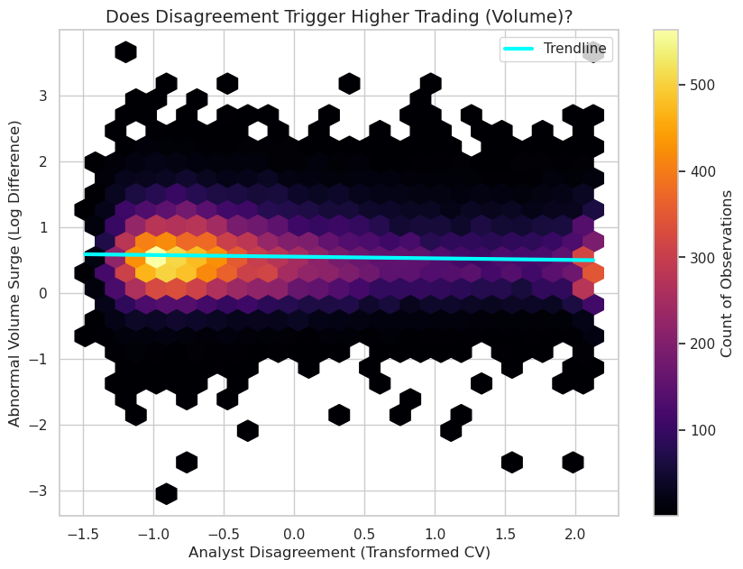

```
--- Volume Surge Regression Results ---
                              OLS Regression Results
=================================================================================
Dep. Variable:     abnormal_volume_surge   R-squared:                       0.032
Model:                               OLS   Adj. R-squared:                  0.032
Method:                    Least Squares   F-statistic:                     91.70
Date:                   Wed, 03 Dec 2025   Prob (F-statistic):          8.61e-206
Time:                           21:29:54   Log-Likelihood:                -21436.
No. Observations:                  30135   AIC:                         4.290e+04
Df Residuals:                      30123   BIC:                         4.300e+04
Df Model:                             11
Covariance Type:               nonrobust
======================================================================================================================
                                                         coef    std err          t      P>|t|      [0.025      0.975]
----------------------------------------------------------------------------------------------------------------------
Intercept                                              0.5823      0.007     89.364      0.000       0.570       0.595
C(instrument_sector)[T.Consumer Staples]              -0.0680      0.014     -4.805      0.000      -0.096      -0.040
C(instrument_sector)[T.Energy]                        -0.2095      0.014    -14.808      0.000      -0.237      -0.182
C(instrument_sector)[T.Financials]                    -0.1909      0.013    -14.356      0.000      -0.217      -0.165
C(instrument_sector)[T.Health Care]                   -0.0258      0.010     -2.583      0.010      -0.045      -0.006
C(instrument_sector)[T.Industrials]                   -0.0310      0.010     -3.207      0.001      -0.050      -0.012
C(instrument_sector)[T.Information Technology]         0.0433      0.008      5.144      0.000       0.027       0.060
C(instrument_sector)[T.Materials]                     -0.1248      0.014     -8.991      0.000      -0.152      -0.098
C(instrument_sector)[T.Telecommunication Services]    -0.0973      0.029     -3.342      0.001      -0.154      -0.040
C(instrument_sector)[T.Utilities]                     -0.3718      0.022    -17.183      0.000      -0.414      -0.329
abs_surprise                                           0.1718      0.033      5.250      0.000       0.108       0.236
revenue_cv_yj                                         -0.0262      0.003     -8.326      0.000      -0.032      -0.020
==============================================================================
Omnibus:                     1493.830   Durbin-Watson:                   1.798
Prob(Omnibus):                  0.000   Jarque-Bera (JB):             2974.155
Skew:                           0.361   Prob(JB):                         0.00
Kurtosis:                       4.360   Cond. No.                         12.3
==============================================================================

Notes:
[1] Standard Errors assume that the covariance matrix of the errors is correctly specified.
```

```python
# Create "Abnormal Volume" Metric
# We use Log Volume to normalize the massive difference between Apple and a small cap.
# Abnormal Volume = Log(Vol After) - Log(Vol Before)
# This represents the "Surge" in liquidity caused by the announcement.
firm_level_data_cleaned['log_vol_after'] = np.log(firm_level_data_cleaned['Trading Volume After Announcement'])
firm_level_data_cleaned['log_vol_before'] = np.log(firm_level_data_cleaned['Trading Volume Before Announcement'])

firm_level_data_cleaned['abnormal_volume_surge'] = (
    firm_level_data_cleaned['log_vol_after'] - firm_level_data_cleaned['log_vol_before']
)

# VISUALIZATION: Does Disagreement Drive Volume?
# We use a Hexbin plot because we have many points, and we want to see the density.
plt.figure(figsize=(10, 7))
hb = plt.hexbin(
    x=firm_level_data_cleaned['revenue_cv_yj'],
    y=firm_level_data_cleaned['abnormal_volume_surge'],
    gridsize=25,
    cmap='inferno',
    mincnt=1
)
cb = plt.colorbar(hb, label='Count of Observations')

# Add a trendline
sns.regplot(
    x='revenue_cv_yj',
    y='abnormal_volume_surge',
    data=firm_level_data_cleaned,
    scatter=False,
    line_kws={'color': 'cyan', 'linewidth': 3},
    label='Trendline'
)

plt.title('Does Disagreement Trigger Higher Trading (Volume)?', fontsize=14)
plt.xlabel('Analyst Disagreement (Transformed CV)')
plt.ylabel('Abnormal Volume Surge (Log Difference)')
plt.legend()
plt.show()

# STATISTICAL TEST
# We control for the magnitude of the surprise ("News") to isolate the effect of "Disagreement" (Opinion).
# Model: Volume_Surge ~ Earnings_Surprise + Disagreement + Sector
print("\n--- Volume Surge Regression Results ---")
model_vol = smf.ols(
    formula="abnormal_volume_surge ~ abs_surprise + revenue_cv_yj + C(instrument_sector)",
    data=firm_level_data_cleaned
).fit()

print(model_vol.summary())
```

We tested the "Difference of Opinion" theory, which states that high disagreement generates trading volume even if it doesn't move the price. If half the market thinks a stock is worth $50 and the other half thinks $100, they will trade shares aggressively with each other to express those views, creating a volume surge.

**Hexbin Plot** visualizes the density of `abnormal_volume_surge` (Y-axis) against `revenue_cv_yj` (X-axis).

- **Observation:** The plot shows a dense concentration of points where volume surges are positive.
- **Trend:** However, visually, the trendline is flat or slightly negative. This is counter-intuitive to the hypothesis.

**Statistical Evidence (Regression)** We ran a multivariate OLS regression to control for sector effects and earnings surprises (`abs_surprise`), as big news naturally generates volume.

- **Coefficient for Disagreement (`revenue_cv_yj`):** -0.0262
- **T-Statistic:** -8.326
- **P-Value:** 0.000 (Highly Significant)

**The Surprising Result** The coefficient is **Negative**.

- **Interpretation:** Higher analyst disagreement leads to **lower** abnormal volume turnover after the announcement.
- **Why?** This supports the **"Wait and See" Hypothesis**. When analysts are fighting (High Disagreement), investors are confused and paralyzed. They stay on the sidelines until the dust settles. Conversely, when there is consensus (Low Disagreement), liquidity flows freely because everyone is on the same side

Contrary to the 'Battleground' hypothesis, we found a statistically significant **negative** relationship between pre-announcement disagreement and post-announcement volume surges ($t = -8.33$). This suggests that extreme ambiguity dries up liquidity. Investors appear risk-averse to 'fog of war' situations, preferring to trade stocks where the consensus is clearer, even if the price move itself is smaller."

This is a **Negative Result**, but very interesting. **Disagreement increases Price Volatility (Risk) but decreases Volume (Liquidity).** That is a dangerous combination (gaps in price).